# Let's load and Process the data

# Imputing missing values

The presence of missing days may introduce bias into some calculations or summaries of the data. 1.Calculate and report the total number of missing values in the dataset (i.e. the total number of rows with NAs)

```r
sumNA <- summarise(activity, sum = sum(is.na(steps)))
sumNA #2304
```

```
## Source: local data frame [1 x 1]
##
##    sum
## 1 2304
```

1. Devise a strategy for filling in all of the missing values in the dataset

```r
MEAN <- summarise(activity, mean = mean(is.na(steps))) #.1311475
```

```r
filled <- activity %>%
  mutate(steps = replace(steps, is.na(steps), mean(steps, na.rm =TRUE)))
```

Calc the daily number of steps along with the mean and median

```r
dailyFilledSteps <- filled %>%
  group_by(date) %>%
  summarise(numSteps = sum(steps)) %>%
  mutate(MEAN = mean(numSteps), MEDIAN= median(numSteps))
```

Make the histogram

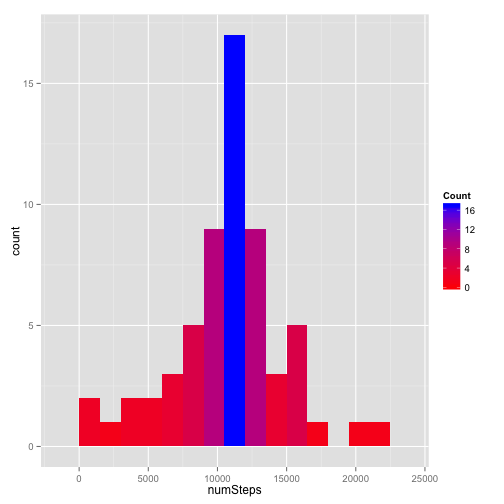

```r
FilledSteps<- ggplot(dailyFilledSteps, aes(x=numSteps))
FilledSteps + geom_histogram(aes(fill = ..count..),binwidth=1500) + scale_fill_gradient("Count", low = "red", high = "blue")
```

#Are there differences in activity patterns between weekdays and weekends? For this part the weekdays() function may be of some help here. Use the dataset with the filled-in missing values for this part.

1.Create a new factor variable in the dataset with two levels – “weekday” and “weekend” indicating whether a given date is a weekday or weekend day. If weekday is Saturday or Sunday, replace with ‘weekend’, else replace with ‘weekday’, use those as factors

```r
dayCategories <- filled %>%
  mutate(TypeOfDay=weekdays(as.Date(date))) %>%
  mutate(TypeOfDay = as.factor(ifelse(TypeOfDay == "Saturday" | TypeOfDay == "Sunday","Weekend","Weekday"))) %>%
  group_by(interval,TypeOfDay) %>%
  mutate(AvgStepsPerInterval = mean(steps))
```

2.Make a panel plot containing a time series plot (i.e. type = “l”) of the 5-minute interval (x-axis) and the average number of steps taken, averaged across all weekday days or weekend days (y-axis).

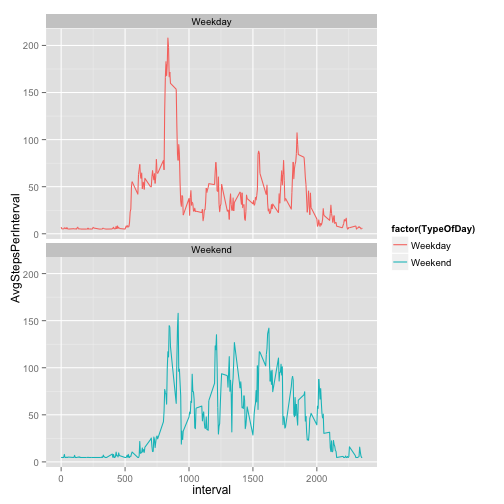

```r
CategoryPlot <- ggplot(dayCategories, aes(x=interval, y= AvgStepsPerInterval))
CategoryPlot + facet_wrap(~TypeOfDay, ncol=1) + geom_line(aes(color = factor(TypeOfDay)))
```